# A2 - Individual assignment - - OMODESOLA AFOLABI

## A2_Unsupervised Learning Case Study (Individual))

#### DAT-5329 | Introduction to Machine Learning & Ai

Omodesola Afolabi  
MBAN DD  
Hult International Business School

### Problem Summary statement

The purpose of this analysis is to understand mobile app download behaviors and the associated consumer patterns by segmenting users using unsupervised machine learning techniques. The dataset contains survey responses from mobile app users, covering a broad spectrum of questions about app usage, preferences, and demographics. By analyzing the data, the analysis was aimed at identifying distinct user segments that can inform targeted marketing strategies. Segmentation is important for the marketing team because it will help with better improved promotional campaigns, broader user engagement, and boost app downloads. The analysis involves processes such as exploratory data analysis (EDA), data preparation, clustering using K-Means, and visualization of the results. In addition to the cluster analysis I thought about implementing Principal Component Analysis (PCA) to reduce spacing and improve clustering performance.

By differentiating users and implementing strategic marketing ideas powered with data, the experiment aims to craft personalized messages that resonate with specific user segments, tailor the app experience to address the unique needs of each user group, and focus marketing efforts on user segments with the highest download potential. This detailed approach not only enhances marketing efforts but also greatly improves the overall user experience, providing actionable insights that drive marketing decisions. Ultimately, the goal is to improve user retention, attract new users, and optimize business outcomes.

### Key insights

Several insights stood out, including segmentation based on app usage, demographics, feedback and reviews, user engagement, and personalized user experience (UI/UX).

Brief on Each Insight

1. Segmentation- The analysis revealed that each segment had different ways of using and downloading the app.
2. Demographics- This insight focuses on the audience that uses the app, such as identifying younger users, gender differences, and regional preferences or engagement levels with the app.
3. Categories with User Engagement - Social media and entertainment platforms showed higher engagement compared to other apps.
4. Feedback & Reviews - Positive reviews were correlated with an increase in downloads, while negative reviews led to a drop in ratings and a reduction in downloads.
5. User Experience and Personalization- Users appreciate customized content and recommendations based on their views and engagement with the app.

### Recommendations

Segmentation on App Usage

Develop a loyalty program for frequent users, offering incentives like exclusive offers and better customization for recommended features. Regularly alert these users about new features within the app. For intermediate users, notify them about discounts and benefits through short ads. To increase engagement, implement a treasure hunt within the app for unlocking certain features. Simplify the user experience and provide short tutorials or interactive guides to help users navigate new features.

Demographics

Create age-appropriate content and collaborate with both upcoming and popular influencers for different age groups. Utilize platforms like Instagram, TikTok, and YouTube for younger audiences, while including Snapchat, Facebook, and LinkedIn for older users. Develop content tailored to each age group and continuously track and analyze campaign performance to refine strategies.

Categories with User Engagement

Promote the most engaging app categories prominently in marketing campaigns and app store listings. Feature top-performing apps in newsletters and on social media. Use in-app recommendations to highlight popular categories, ensuring users are aware of and engaged with the most compelling content.

Feedback & Reviews

Establishing a feedback loop to monitor and address user reviews promptly. Encourage satisfied users to leave positive reviews through in-app prompts and incentives. Actively respond to negative reviews with solutions and updates, demonstrating a commitment to user satisfaction and improving the app's reputation.

User Experience and Personalization

Implement algorithms to provide custom or personalized apps recommendations based on user behavior and preferences. Allow users to customize their app interface with options like themes and layout adjustments. Use behavioral insights to deliver targeted content and notifications, enhancing the overall user experience and engagement.

By these recommendations, the marketing department can effectively gain more traction with the campagnes and will be able to understand a need for improvement in any area from strategises listed

### Problem Summary Statement

The purpose of this analysis is to understand mobile app download behaviors and the associated consumer patterns by segmenting users using unsupervised machine learning techniques. The dataset contains survey responses from mobile app users, covering a broad spectrum of questions about app usage, preferences, and demographics. By analyzing the data, the analysis was aimed at identifying distinct user segments that can inform targeted marketing strategies. Segmentation is important for the marketing team because it will help with better promotional campaigns, broader user engagement, and boost app downloads. The analysis involves processes such as exploratory data analysis (EDA), data preparation, clustering using K-Means, and visualization of the results. In addition to the cluster analysis, I thought about implementing Principal Component Analysis (PCA) to reduce spacing and improve clustering performance.

By differentiating users and implementing strategic marketing ideas powered with data, the experiment aims to craft personalized messages that resonate with specific user segments, tailor the app experience to address the unique needs of each user group, and focus marketing efforts on user segments with the highest download potential. This detailed approach not only enhances marketing efforts but also greatly improves the overall user experience, providing actionable insights that drive marketing decisions. Ultimately, the goal is to improve user retention, attract new users, and optimize business outcomes.

### Key Insights

Several insights stood out, including segmentation based on app usage, demographics, feedback and reviews, user engagement, and personalized user experience (UI/UX).

#### Brief on Each Insight

1. Segmentation - The analysis revealed that each segment had different ways of using and downloading the app.
2. Demographics - This insight focuses on the audience that uses the app, such as identifying younger users, gender differences, and regional preferences or engagement levels with the app.
3. Categories with User Engagement - Social media and entertainment platforms showed higher engagement compared to other apps.
4. Feedback & Reviews - Positive reviews were correlated with an increase in downloads, while negative reviews led to a drop in ratings and a reduction in downloads.
5. User Experience and Personalization** - Users appreciate customized content and recommendations based on their views and engagement with the app.

### Recommendations

#### Segmentation on App Usage

Develop a loyalty program for frequent users, offering incentives like exclusive offers and better customization for recommended features. Regularly alert these users about new features within the app. For intermediate users, notify them about discounts and benefits through short ads. To increase engagement, implement a treasure hunt within the app for unlocking certain features. Simplify the user experience and provide short tutorials or interactive guides to help users navigate new features.

#### Demographics

Create age-appropriate content and collaborate with both upcoming and popular influencers for different age groups. Utilize platforms like Instagram, TikTok, and YouTube for younger audiences, while including Snapchat, Facebook, and LinkedIn for older users. Develop content tailored to each age group and continuously track and analyze campaign performance to refine strategies.

#### Categories with User Engagement

Promote the most engaging app categories prominently in marketing campaigns and app store listings. Feature top-performing apps in newsletters and on social media. Use in-app recommendations to highlight popular categories, ensuring users are aware of and engaged with the most compelling content.

#### Feedback & Reviews

Establish a feedback loop to monitor and address user reviews promptly. Encourage satisfied users to leave positive reviews through in-app prompts and incentives. Actively respond to negative reviews with solutions and updates, demonstrating a commitment to user satisfaction and improving the app's reputation.

#### User Experience and Personalization

Implement algorithms to provide custom or personalized app recommendations based on user behavior and preferences. Allow users to customize their app interface with options like themes and layout adjustments. Use behavioral insights to deliver targeted content and notifications, enhancing the overall user experience and engagement.

By following these recommendations, the marketing department can effectively gain more traction with their campaigns and will be able to understand the need for improvement in any area from the strategies listed.

```python
import pandas as pd
import matplotlib.pyplot as plt
import numpy as np
import seaborn as sns
from sklearn.preprocessing import StandardScaler
from sklearn.cluster import KMeans
from sklearn.metrics import silhouette_score
from sklearn.decomposition import PCA
```

```python
mas_data = pd.read_excel('./datasets/Mobile_App_Survey_Data.xlsx')

# Display the first few rows of the dataset to understand its structure
mas_data.head()
```

|  | caseID | q1 | q2r1 | q2r2 | q2r3 | q2r4 | q2r5 | q2r6 | q2r7 | q2r8 | ... | q49 | q50r1 | q50r2 | q50r3 | q50r4 | q50r5 | q54 | q55 | q56 | q57 |
| --- | --- | --- | --- | --- | --- | --- | --- | --- | --- | --- | --- | --- | --- | --- | --- | --- | --- | --- | --- | --- | --- |
| 0 | 355 | 5 | 0 | 1 | 1 | 0 | 0 | 0 | 0 | 0 | ... | 1 | 0 | 0 | 0 | 1 | 0 | 1 | 2 | 11 | 1 |
| 1 | 1397 | 3 | 0 | 0 | 1 | 0 | 0 | 0 | 0 | 0 | ... | 2 | 1 | 0 | 0 | 0 | 0 | 2 | 2 | 9 | 2 |
| 2 | 1197 | 2 | 0 | 1 | 1 | 0 | 0 | 0 | 0 | 0 | ... | 2 | 1 | 0 | 0 | 0 | 0 | 1 | 2 | 8 | 2 |
| 3 | 484 | 2 | 0 | 0 | 0 | 0 | 1 | 0 | 0 | 0 | ... | 2 | 1 | 0 | 0 | 0 | 0 | 2 | 2 | 1 | 1 |
| 4 | 2113 | 4 | 0 | 0 | 0 | 1 | 0 | 0 | 0 | 0 | ... | 1 | 0 | 1 | 0 | 0 | 0 | 1 | 2 | 11 | 2 |

5 rows × 88 columns

# EDA & DP

```
Missing Values:
 caseID    0
q1        0
q2r1      0
q2r2      0
q2r3      0
         ..
q50r5     0
q54       0
q55       0
q56       0
q57       0
Length: 88, dtype: int64

Descriptive Statistics:
             caseID           q1         q2r1         q2r2         q2r3  \
count  1552.000000  1552.000000  1552.000000  1552.000000  1552.000000
mean   1192.854381     4.506443     0.503222     0.240979     0.364046
std     712.006709     2.400829     0.500151     0.427816     0.481317
min       1.000000     1.000000     0.000000     0.000000     0.000000
25%     570.750000     2.000000     0.000000     0.000000     0.000000
50%    1144.500000     4.000000     1.000000     0.000000     0.000000
75%    1833.500000     6.000000     1.000000     0.000000     1.000000
max    2396.000000    11.000000     1.000000     1.000000     1.000000

              q2r4         q2r5         q2r6         q2r7         q2r8  ...  \
count  1552.000000  1552.000000  1552.000000  1552.000000  1552.000000  ...
mean      0.201031     0.055412     0.088273     0.041237     0.193943  ...
std       0.400900     0.228857     0.283783     0.198902     0.395512  ...
min       0.000000     0.000000     0.000000     0.000000     0.000000  ...
25%       0.000000     0.000000     0.000000     0.000000     0.000000  ...
50%       0.000000     0.000000     0.000000     0.000000     0.000000  ...
75%       0.000000     0.000000     0.000000     0.000000     0.000000  ...
max       1.000000     1.000000     1.000000     1.000000     1.000000  ...

               q49        q50r1        q50r2        q50r3        q50r4  \
count  1552.000000  1552.000000  1552.000000  1552.000000  1552.000000
mean      1.898196     0.500644     0.186211     0.181057     0.147552
std       0.934997     0.500161     0.389403     0.385189     0.354769
min       1.000000     0.000000     0.000000     0.000000     0.000000
25%       1.000000     0.000000     0.000000     0.000000     0.000000
50%       2.000000     1.000000     0.000000     0.000000     0.000000
75%       2.000000     1.000000     0.000000     0.000000     0.000000
max       4.000000     1.000000     1.000000     1.000000     1.000000

             q50r5          q54          q55          q56          q57
count  1552.000000  1552.000000  1552.000000  1552.000000  1552.000000
mean      0.160438     1.729381     1.846005     7.802835     1.528995
std       0.367130     1.487177     0.361060     3.724357     0.499319
min       0.000000     1.000000     1.000000     1.000000     1.000000
25%       0.000000     1.000000     2.000000     5.000000     1.000000
50%       0.000000     1.000000     2.000000     7.500000     2.000000
75%       0.000000     2.000000     2.000000    11.000000     2.000000
max       1.000000     6.000000     2.000000    14.000000     2.000000

[8 rows x 88 columns]
```

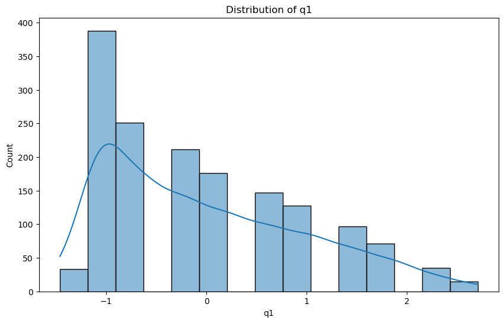

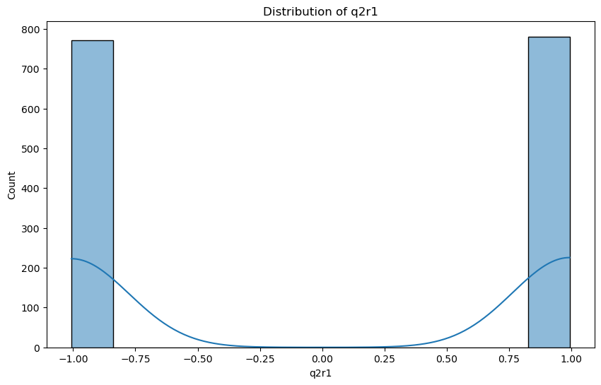

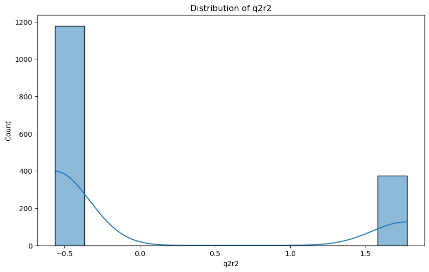

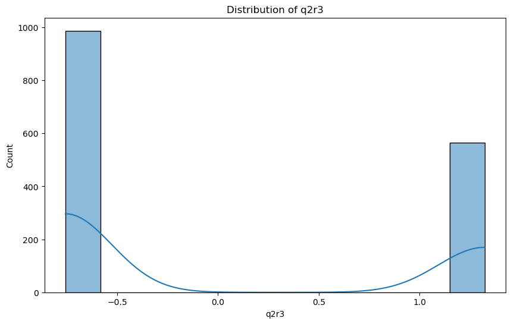

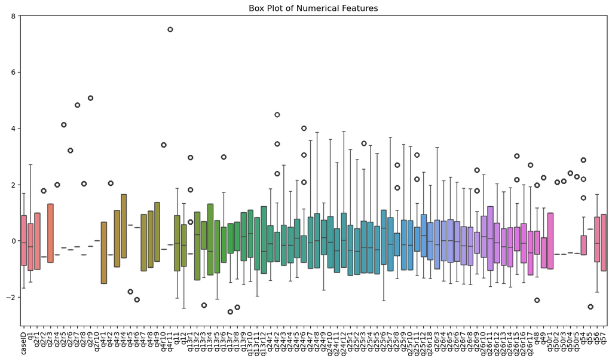

```python
# Check for missing values
values_missing = mas_data.isnull().sum()
print("Missing Values:\n", values_missing)

# Drop any missing values
mas_data_cleaned = mas_data.dropna()

# Descriptive statistics
descriptive_stats = mas_data_cleaned.describe()
print("\nDescriptive Statistics:\n", descriptive_stats)

# Standardize numerical features
scaler = StandardScaler()
numerical_features = mas_data_cleaned.select_dtypes(include=['float64', 'int64']).columns
mas_data_cleaned[numerical_features] = scaler.fit_transform(mas_data_cleaned[numerical_features])

# Visualize the distribution of a few key numerical features
key_features = ['q1', 'q2r1', 'q2r2', 'q2r3']  # Features
for feature in key_features:
    plt.figure(figsize=(10, 6))
    sns.histplot(mas_data_cleaned[feature], kde=True)
    plt.title(f'Distribution of {feature}')
    plt.show()

# Box plot for numerical features- Summerized
plt.figure(figsize=(15, 8))
sns.boxplot(data=mas_data_cleaned[numerical_features])
plt.xticks(rotation=90)
plt.title('Box Plot of Numerical Features')
plt.show()
```

Due to the number of survey questions I had selected the first cluster that consist of 4 survey question which consist of mean, standard deviation,min and some more details of interquartile ranges .

#### Graph 1 q1

How is this beneficial to the marketing team? This helps the team strategically group personalized messages to individuals. For example, users in group 0 might get different promotions than those in groups 1 or 2.

#### Graph 2 q2r1

The graph focuses on feature "q2r1." We can see that each group has different information that can help with analysis, and here we see two distinctive groups that go for both the low value of -1.00 and high value of 1.00. Also, q2r1 focuses more on the frequent use of the app. To gain traction in this market, issuing a loyalty program could be offered because the graph shows people who hardly use it, and this could bring customers back to using the app.

#### Graph 3 q2r2

This graph highlights that a lot of users are gravitating to the left side of the scale. The bar chart is distinctively clear where the response to the negative spectrum is significant. What can be inferred is that in order to gain more customers to use the app, they need to create more sophisticated tutorials for people in the lower sections and warmly win them to gain more retention. People in the other section can gain cool features or unique upgrades.

#### Graph 5 Box plot of numerical features

This graph is unique because it is used to track user behavior and how long a user uses the app across all the features. It is like a mini-map to discover outliers. The central line within each box represents the median value of the feature. The edges of the box represent the first and third quartiles (Q1 and Q3), while the whiskers extend to the minimum and maximum values within 1.5 times the IQR from Q1 and Q3. Any data points outside this range are considered outliers and are plotted as individual points.

# Using the Elbow Method to determine the number of clusters

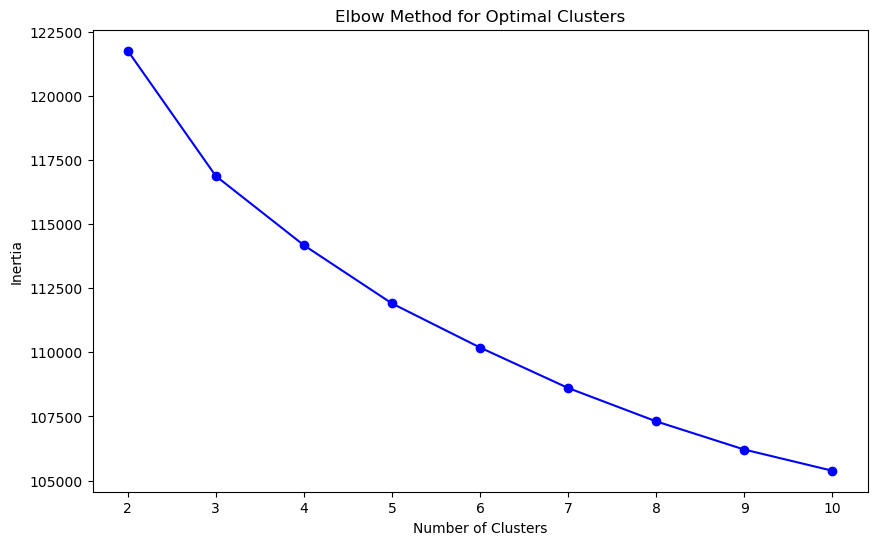

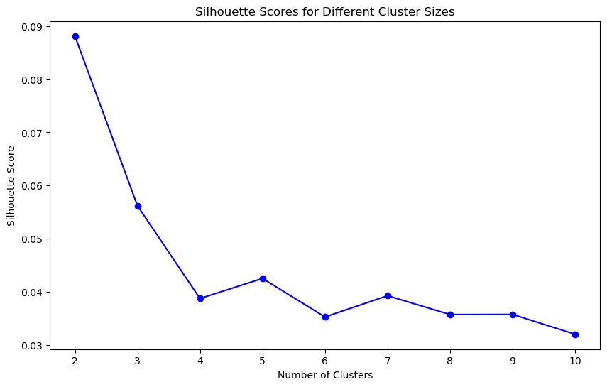

```
Silhouette Score for 3 clusters: 0.05621985814037492
```

```python
# Determine the optimal number of clusters using the Elbow Method and Silhouette Analysis
inertia = []
silhouette_scores = []
K = range(2, 11)

for k in K:
    kmeans = KMeans(n_clusters=k, random_state=42, n_init=10)
    kmeans.fit(mas_data_cleaned[numerical_features])
    inertia.append(kmeans.inertia_)
    silhouette_avg = silhouette_score(mas_data_cleaned[numerical_features], kmeans.labels_)
    silhouette_scores.append(silhouette_avg)

# Plot the Elbow Method results
plt.figure(figsize=(10, 6))
plt.plot(K, inertia, 'bo-')
plt.xlabel('Number of Clusters')
plt.ylabel('Inertia')
plt.title('Elbow Method for Optimal Clusters')
plt.show()

# Plot the Silhouette Scores
plt.figure(figsize=(10, 6))
plt.plot(K, silhouette_scores, 'bo-')
plt.xlabel('Number of Clusters')
plt.ylabel('Silhouette Score')
plt.title('Silhouette Scores for Different Cluster Sizes')
plt.show()

# Assume the optimal number of clusters is chosen based on the above analysis
optimal_clusters = 3
kmeans = KMeans(n_clusters=optimal_clusters, random_state=42, n_init=10)
clusters = kmeans.fit_predict(mas_data_cleaned[numerical_features])

# Add cluster labels to the data
mas_data_cleaned['Cluster'] = clusters

# Calculate the Silhouette Score for the chosen number of clusters
silhouette_avg = silhouette_score(mas_data_cleaned[numerical_features], clusters)
print(f'Silhouette Score for {optimal_clusters} clusters: {silhouette_avg}')
```

#### Graph 6 - Elbow Method

The elbow method is an interesting technique used to gain more insight into the optimal number of clusters from the dataset. What can be inferred from this graph is that as the number of clusters increases, the inertia decreases. Where the elbow is observed is where the rate slows down at a sharp angle. How does this data help the marketing team? It helps them gain more insight into where to allocate money and what the target of their marketing should be. Each cluster indicates different levels of users, which can help in gaining more customers in different levels with personalized messages.

#### Graph 7 - Silhouette score

The silhouette score is used to analyze different clusters and compare them with each other. It also signifies that if a score is higher, it was separated properly for comparison. This can be very beneficial for the marketing team to focus more on a special group, which is good for a target niche. When users receive relevant messages, they're more likely to engage with the app, leading to happier and more loyal users.

# Summarized Group Clusters for Interpretations

```
Cluster Summary:
            caseID        q1      q2r1      q2r2      q2r3      q2r4      q2r5  \
Cluster
0        0.304111  0.130113  0.203071 -0.035365 -0.077213 -0.179052 -0.177257
1       -0.310842  0.084186 -0.292164 -0.202347 -0.006323  0.023439 -0.039690
2       -0.120916 -0.363364  0.040649  0.356279  0.153019  0.300168  0.387406

             q2r6      q2r7      q2r8  ...       q49     q50r1     q50r2  \
Cluster                                ...
0       -0.201168 -0.170026  0.043128  ...  0.000817  0.059633 -0.081380
1        0.008673 -0.013212 -0.251271  ...  0.042825 -0.082370 -0.032024
2        0.362586  0.335932  0.280147  ... -0.062973  0.007022  0.197665

            q50r3     q50r4     q50r5       q54       q55       q56       q57
Cluster
0       -0.049590  0.019682  0.048685 -0.064838  0.084962  0.157918  0.020797
1        0.016106 -0.013237  0.099378  0.014518  0.052251 -0.139930 -0.100630
2        0.069338 -0.017700 -0.233360  0.100044 -0.233367 -0.093614  0.105623

[3 rows x 88 columns]
```

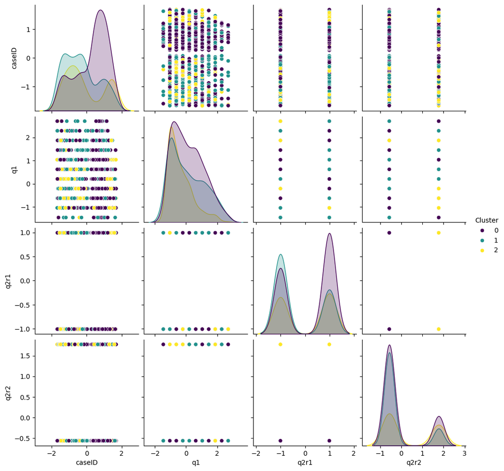

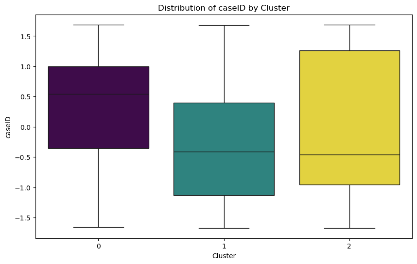

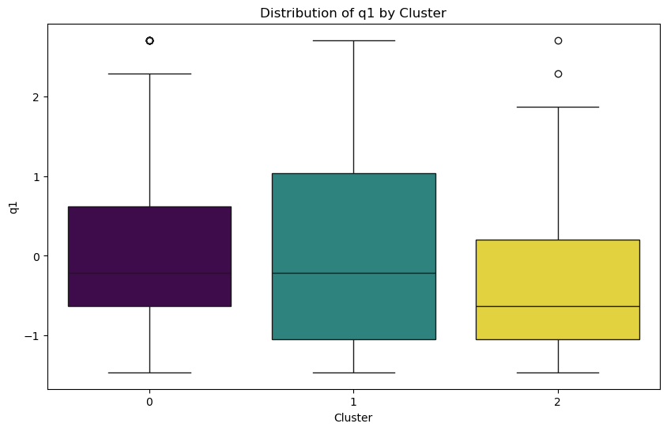

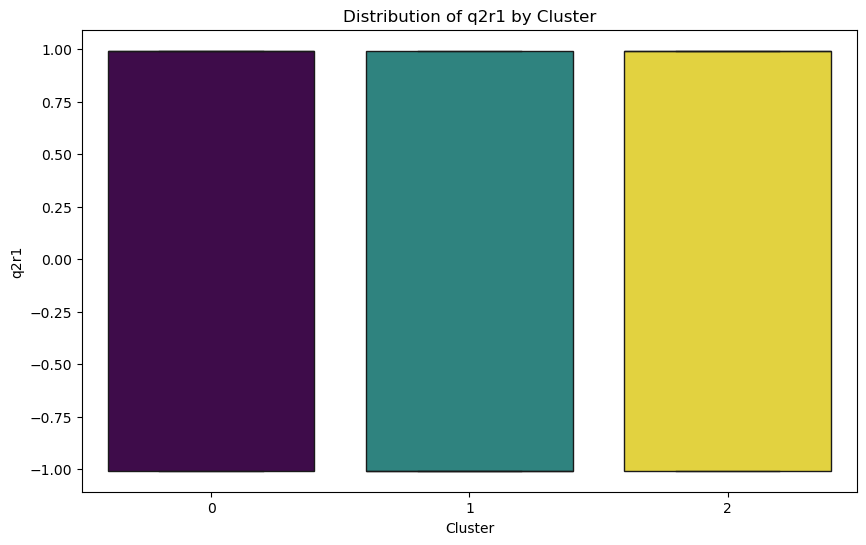

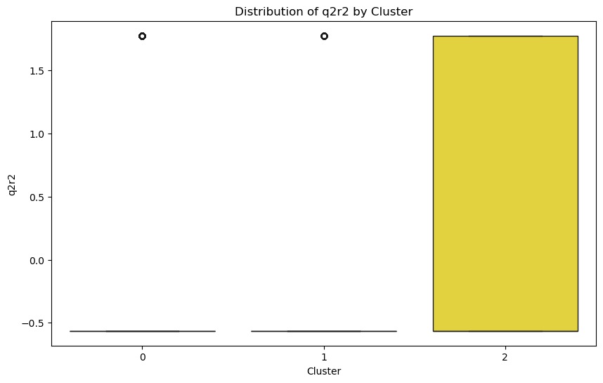

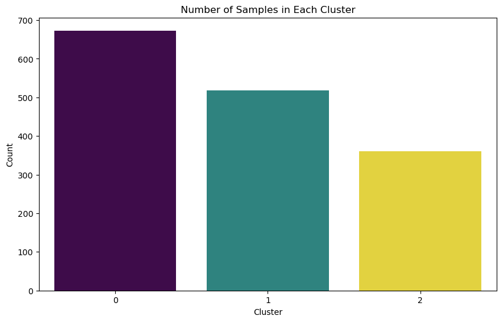

```python
# Summarize the characteristics of each cluster
cluster_summary = mas_data_cleaned.groupby('Cluster').mean()
print("\nCluster Summary:\n", cluster_summary)

# Selected subset of features for pair plot visualization
selected_features = numerical_features[:4]  # Select features relevant to the analysis

# Visualize the clusters using a pair plot for the subset of features
sns.pairplot(mas_data_cleaned[selected_features.tolist() + ['Cluster']], hue='Cluster', palette='viridis')
plt.show()

# Create box plots for each selected feature by cluster
for feature in selected_features:
    plt.figure(figsize=(10, 6))
    sns.boxplot(x='Cluster', y=feature, data=mas_data_cleaned, hue='Cluster', palette='viridis', legend=False)
    plt.title(f'Distribution of {feature} by Cluster')
    plt.xlabel('Cluster')
    plt.ylabel(feature)
    plt.show()

# Create a count plot to show the number of samples in each cluster
plt.figure(figsize=(10, 6))
sns.countplot(x='Cluster', data=mas_data_cleaned, hue='Cluster', palette='viridis', legend=False)
plt.title('Number of Samples in Each Cluster')
plt.xlabel('Cluster')
plt.ylabel('Count')
plt.show()
```

I selected only 3 clusters to focus on. The cluster summary helps in understanding the unique profiles of each cluster. This is advantageous in terms of how to target the users.

### Pair plot of selected features by clusters

The pair plot visualizes the relationships between selected features (caseID, q1, q2r1, q2r2) across the identified clusters (0, 1, 2). All the displayed scatter plots show a distribution of points in the cluster, offering more understanding of how these variables correlate with each other. The diagonal plots represent the distribution of each feature, highlighting variations and overlaps among clusters. This visualization aids in understanding the internal structure of the clusters and the significance of each feature in differentiating between clusters. By understanding these key features, we can craft targeted marketing messages that resonate with each user segment.

### Distribution of caseID by cluster

This box plot shows how a unique identifier (caseID) is spread out across different user groups. Imagine boxes with lines that represent the range and center point of caseID for each group. We also can see some groups have more variation within caseID than others. What the marketing team can do is to tailor campaigns to the unique characteristics of users in each group, ensuring the champagne reaches the right target audience.n

### Distribution of q1, q2r1 , q2r2 by cluster

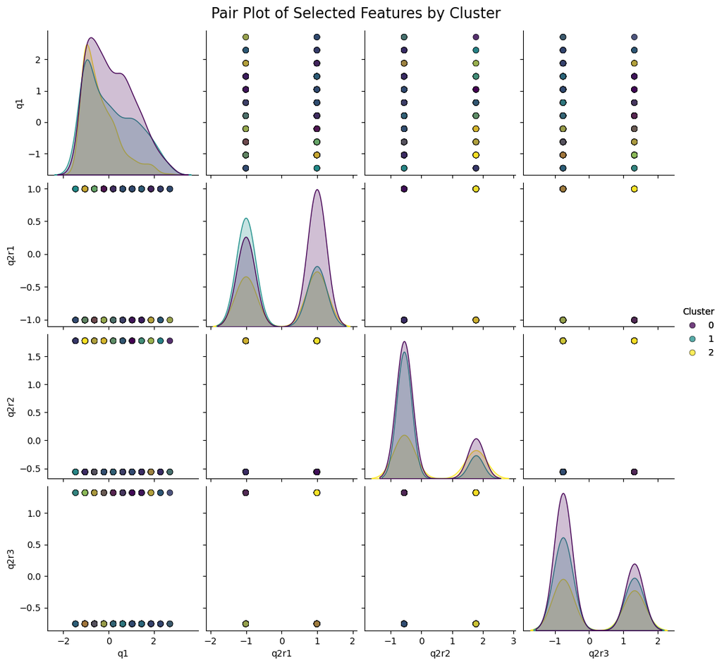

```python
# Select the most relevant features for pair plot visualization
selected_features = ['q1', 'q2r1', 'q2r2', 'q2r3']  # Adjust based on the analysis

# Create a pair plot for the selected features
plt.figure(figsize=(12, 10))
pair_plot = sns.pairplot(mas_data_cleaned[selected_features + ['Cluster']],
                         hue='Cluster',
                         palette='viridis',
                         diag_kind='kde',
                         plot_kws={'alpha': 0.5, 's': 40, 'edgecolor': 'k'},
                         height=2.5)

# Enhance plot aesthetics
pair_plot.fig.suptitle('Pair Plot of Selected Features by Cluster', y=1.02, fontsize=16)
pair_plot.add_legend(title='Cluster')

# Show the plot
plt.show()
```

### Pair plot

We have another pair plot here, but there is a difference from its previous version. This pair plot dives into how user characteristics (q1, q2r1, etc.) relate to each other within different user groups. Imagine a grid of mini-scatter plots, where each explores how two features are linked for a specific user group. Diagonal plots show how individual features are distributed across the groups.

By understanding these relationships, the marketing team can create targeted campaigns. If users in Cluster 0 have different preferences than those in Cluster 1 (based on q1), separate marketing messages can be crafted for each group to resonate better. This also helps identify key features for segmentation and personalize the user experience – users in different clusters might prefer different content or functionalities.

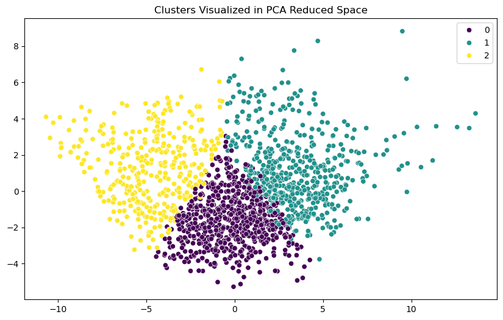

```python
# Perform PCA
pca = PCA(n_components=0.95)  # Retain 95% of the variance
principal_components = pca.fit_transform(mas_data_cleaned[numerical_features])

# Use principal components for clustering
kmeans = KMeans(n_clusters=optimal_clusters, random_state=42, n_init=10)
clusters = kmeans.fit_predict(principal_components)

# To add cluster labels to the data
mas_data_cleaned['Cluster_PCA'] = clusters

# Visualize clusters in PCA reduced space
plt.figure(figsize=(10, 6))
sns.scatterplot(x=principal_components[:, 0], y=principal_components[:, 1], hue=clusters, palette='viridis')
plt.title('Clusters Visualized in PCA Reduced Space')
plt.show()
```